# Project: Investigate a Dataset (TMDb Movies Dataset)

- Introduction
- Data Wrangling
- Exploratory Data Analysis
- Conclusions

## Introduction

This project is for investigating the TMDb Movies Dataset, investigating the data will help providing the interesting and desired insights, these insights can be helpful for people working in the entetainment industry, this insights is also for the people to compare the movies, their genres and according to the other attributes.

### Context

Want to make a movie with highest profits and hits? You have come to right place! Also we are going to find other interesting stuffs about movies that our data is telling us.

This dataset contains observations of 10k+ movies like title, budget, revenue, cast, director, tagline, keywords, genres, release date, runtime etc.

Using this dataset , we can gain and answer some interesting questions like,

1. Which movies are the most profitable?
2. Which are the top production companies?
3. Who are the top rated directors?
4. Which months has witnessed the most popular movies, is there any relation between them?
5. Is there any relation between Budget and the revenue of the movies?

The process of Data Cleaning, Data Manipulation and Exploratory Data Analysis will help answering this questions

### Importing the required python libraries

```python
import pandas as pd
import numpy as np
import matplotlib.pyplot as plt
%matplotlib inline
import seaborn as sns
sns.set_style('darkgrid')
```

### Loading the dataset into the jupyter notebook

```python
df = pd.read_csv('/Users/ahuja/Desktop/tmdb_movies_data 2.csv')
df.head()
```

|  | id | imdb_id | popularity | budget | revenue | original_title | cast | homepage | director | tagline | ... | overview | runtime | genres | production_companies | release_date | vote_count | vote_average | release_year | budget_adj | revenue_adj |
| --- | --- | --- | --- | --- | --- | --- | --- | --- | --- | --- | --- | --- | --- | --- | --- | --- | --- | --- | --- | --- | --- |
| 0 | 135397 | tt0369610 | 32.985763 | 150000000 | 1513528810 | Jurassic World | Chris Pratt\|Bryce Dallas Howard\|Irrfan Khan\|Vi... | http://www.jurassicworld.com/ | Colin Trevorrow | The park is open. | ... | Twenty-two years after the events of Jurassic ... | 124 | Action\|Adventure\|Science Fiction\|Thriller | Universal Studios\|Amblin Entertainment\|Legenda... | 6/9/2015 | 5562 | 6.5 | 2015 | 137999939.3 | 1.392446e+09 |
| 1 | 76341 | tt1392190 | 28.419936 | 150000000 | 378436354 | Mad Max: Fury Road | Tom Hardy\|Charlize Theron\|Hugh Keays-Byrne\|Nic... | http://www.madmaxmovie.com/ | George Miller | What a Lovely Day. | ... | An apocalyptic story set in the furthest reach... | 120 | Action\|Adventure\|Science Fiction\|Thriller | Village Roadshow Pictures\|Kennedy Miller Produ... | 5/13/2015 | 6185 | 7.1 | 2015 | 137999939.3 | 3.481613e+08 |
| 2 | 262500 | tt2908446 | 13.112507 | 110000000 | 295238201 | Insurgent | Shailene Woodley\|Theo James\|Kate Winslet\|Ansel... | http://www.thedivergentseries.movie/#insurgent | Robert Schwentke | One Choice Can Destroy You | ... | Beatrice Prior must confront her inner demons ... | 119 | Adventure\|Science Fiction\|Thriller | Summit Entertainment\|Mandeville Films\|Red Wago... | 3/18/2015 | 2480 | 6.3 | 2015 | 101199955.5 | 2.716190e+08 |
| 3 | 140607 | tt2488496 | 11.173104 | 200000000 | 2068178225 | Star Wars: The Force Awakens | Harrison Ford\|Mark Hamill\|Carrie Fisher\|Adam D... | http://www.starwars.com/films/star-wars-episod... | J.J. Abrams | Every generation has a story. | ... | Thirty years after defeating the Galactic Empi... | 136 | Action\|Adventure\|Science Fiction\|Fantasy | Lucasfilm\|Truenorth Productions\|Bad Robot | 12/15/2015 | 5292 | 7.5 | 2015 | 183999919.0 | 1.902723e+09 |
| 4 | 168259 | tt2820852 | 9.335014 | 190000000 | 1506249360 | Furious 7 | Vin Diesel\|Paul Walker\|Jason Statham\|Michelle ... | http://www.furious7.com/ | James Wan | Vengeance Hits Home | ... | Deckard Shaw seeks revenge against Dominic Tor... | 137 | Action\|Crime\|Thriller | Universal Pictures\|Original Film\|Media Rights ... | 4/1/2015 | 2947 | 7.3 | 2015 | 174799923.1 | 1.385749e+09 |

5 rows × 21 columns

## Data Wrangling

### **General Properties**

```python
df.info()
```

```
<class 'pandas.core.frame.DataFrame'>
RangeIndex: 10866 entries, 0 to 10865
Data columns (total 21 columns):
 #   Column                Non-Null Count  Dtype
---  ------                --------------  -----
 0   id                    10866 non-null  int64
 1   imdb_id               10856 non-null  object
 2   popularity            10866 non-null  float64
 3   budget                10866 non-null  int64
 4   revenue               10866 non-null  int64
 5   original_title        10866 non-null  object
 6   cast                  10790 non-null  object
 7   homepage              2936 non-null   object
 8   director              10822 non-null  object
 9   tagline               8042 non-null   object
 10  keywords              9373 non-null   object
 11  overview              10862 non-null  object
 12  runtime               10866 non-null  int64
 13  genres                10843 non-null  object
 14  production_companies  9836 non-null   object
 15  release_date          10866 non-null  object
 16  vote_count            10866 non-null  int64
 17  vote_average          10866 non-null  float64
 18  release_year          10866 non-null  int64
 19  budget_adj            10866 non-null  float64
 20  revenue_adj           10866 non-null  float64
dtypes: float64(4), int64(6), object(11)
memory usage: 1.7+ MB
```

```python
rows, columns = df.shape
print("Number of rows:", rows)
print("Number of columns:", columns)
```

```
Number of rows: 10866
Number of columns: 21
```

```python
df.describe()
```

|  | id | popularity | budget | revenue | runtime | vote_count | vote_average | release_year | budget_adj | revenue_adj |
| --- | --- | --- | --- | --- | --- | --- | --- | --- | --- | --- |
| count | 10866.000000 | 10866.000000 | 1.086600e+04 | 1.086600e+04 | 10866.000000 | 10866.000000 | 10866.000000 | 10866.000000 | 1.086600e+04 | 1.086600e+04 |
| mean | 66064.177434 | 0.646441 | 1.462570e+07 | 3.982332e+07 | 102.070863 | 217.389748 | 5.974922 | 2001.322658 | 1.755104e+07 | 5.136436e+07 |
| std | 92130.136561 | 1.000185 | 3.091321e+07 | 1.170035e+08 | 31.381405 | 575.619058 | 0.935142 | 12.812941 | 3.430616e+07 | 1.446325e+08 |
| min | 5.000000 | 0.000065 | 0.000000e+00 | 0.000000e+00 | 0.000000 | 10.000000 | 1.500000 | 1960.000000 | 0.000000e+00 | 0.000000e+00 |
| 25% | 10596.250000 | 0.207583 | 0.000000e+00 | 0.000000e+00 | 90.000000 | 17.000000 | 5.400000 | 1995.000000 | 0.000000e+00 | 0.000000e+00 |
| 50% | 20669.000000 | 0.383856 | 0.000000e+00 | 0.000000e+00 | 99.000000 | 38.000000 | 6.000000 | 2006.000000 | 0.000000e+00 | 0.000000e+00 |
| 75% | 75610.000000 | 0.713817 | 1.500000e+07 | 2.400000e+07 | 111.000000 | 145.750000 | 6.600000 | 2011.000000 | 2.085325e+07 | 3.369710e+07 |
| max | 417859.000000 | 32.985763 | 4.250000e+08 | 2.781506e+09 | 900.000000 | 9767.000000 | 9.200000 | 2015.000000 | 4.250000e+08 | 2.827124e+09 |

#### By analysing the data using descriptive statistics, I found that some features are not required for the answering the research questions, moreover, they also contains uniques values, which doesn't help answering the research questions.

```python
#removing unwanted columns
df.drop(['imdb_id', 'homepage', 'tagline', 'overview','budget_adj','revenue_adj','keywords'], axis=1, inplace=True)
```

```python
df.dtypes
```

```
id                        int64
popularity              float64
budget                    int64
revenue                   int64
original_title           object
cast                     object
director                 object
runtime                   int64
genres                   object
production_companies     object
release_date             object
vote_count                int64
vote_average            float64
release_year              int64
dtype: object
```

**It was observed that release_date column's data type was an object, thus converting it to datatime datatype to create desired insights**

```python
#changing format of some attributes
df['release_date'] = pd.to_datetime(df['release_date'])
df['release_date'].head(5)
```

```
0   2015-06-09
1   2015-05-13
2   2015-03-18
3   2015-12-15
4   2015-04-01
Name: release_date, dtype: datetime64[ns]
```

```python
df.head()
```

|  | id | popularity | budget | revenue | original_title | cast | director | runtime | genres | production_companies | release_date | vote_count | vote_average | release_year |
| --- | --- | --- | --- | --- | --- | --- | --- | --- | --- | --- | --- | --- | --- | --- |
| 0 | 135397 | 32.985763 | 150000000 | 1513528810 | Jurassic World | Chris Pratt\|Bryce Dallas Howard\|Irrfan Khan\|Vi... | Colin Trevorrow | 124 | Action\|Adventure\|Science Fiction\|Thriller | Universal Studios\|Amblin Entertainment\|Legenda... | 2015-06-09 | 5562 | 6.5 | 2015 |
| 1 | 76341 | 28.419936 | 150000000 | 378436354 | Mad Max: Fury Road | Tom Hardy\|Charlize Theron\|Hugh Keays-Byrne\|Nic... | George Miller | 120 | Action\|Adventure\|Science Fiction\|Thriller | Village Roadshow Pictures\|Kennedy Miller Produ... | 2015-05-13 | 6185 | 7.1 | 2015 |
| 2 | 262500 | 13.112507 | 110000000 | 295238201 | Insurgent | Shailene Woodley\|Theo James\|Kate Winslet\|Ansel... | Robert Schwentke | 119 | Adventure\|Science Fiction\|Thriller | Summit Entertainment\|Mandeville Films\|Red Wago... | 2015-03-18 | 2480 | 6.3 | 2015 |
| 3 | 140607 | 11.173104 | 200000000 | 2068178225 | Star Wars: The Force Awakens | Harrison Ford\|Mark Hamill\|Carrie Fisher\|Adam D... | J.J. Abrams | 136 | Action\|Adventure\|Science Fiction\|Fantasy | Lucasfilm\|Truenorth Productions\|Bad Robot | 2015-12-15 | 5292 | 7.5 | 2015 |
| 4 | 168259 | 9.335014 | 190000000 | 1506249360 | Furious 7 | Vin Diesel\|Paul Walker\|Jason Statham\|Michelle ... | James Wan | 137 | Action\|Crime\|Thriller | Universal Pictures\|Original Film\|Media Rights ... | 2015-04-01 | 2947 | 7.3 | 2015 |

**Converting the Runtime column values in more generalised format for better data understanding**

```python
#using lambda to convert the time into more generalised format
df.runtime = df.runtime.apply(lambda x: '{:02d}h: {:02d}m'.format(*divmod(x, 60)))
df.runtime
```

```
0        02h: 04m
1        02h: 00m
2        01h: 59m
3        02h: 16m
4        02h: 17m
           ...
10861    01h: 35m
10862    02h: 56m
10863    01h: 34m
10864    01h: 20m
10865    01h: 14m
Name: runtime, Length: 10866, dtype: object
```

```python
df.head()
```

|  | id | popularity | budget | revenue | original_title | cast | director | runtime | genres | production_companies | release_date | vote_count | vote_average | release_year |
| --- | --- | --- | --- | --- | --- | --- | --- | --- | --- | --- | --- | --- | --- | --- |
| 0 | 135397 | 32.985763 | 150000000 | 1513528810 | Jurassic World | Chris Pratt\|Bryce Dallas Howard\|Irrfan Khan\|Vi... | Colin Trevorrow | 02h: 04m | Action\|Adventure\|Science Fiction\|Thriller | Universal Studios\|Amblin Entertainment\|Legenda... | 2015-06-09 | 5562 | 6.5 | 2015 |
| 1 | 76341 | 28.419936 | 150000000 | 378436354 | Mad Max: Fury Road | Tom Hardy\|Charlize Theron\|Hugh Keays-Byrne\|Nic... | George Miller | 02h: 00m | Action\|Adventure\|Science Fiction\|Thriller | Village Roadshow Pictures\|Kennedy Miller Produ... | 2015-05-13 | 6185 | 7.1 | 2015 |
| 2 | 262500 | 13.112507 | 110000000 | 295238201 | Insurgent | Shailene Woodley\|Theo James\|Kate Winslet\|Ansel... | Robert Schwentke | 01h: 59m | Adventure\|Science Fiction\|Thriller | Summit Entertainment\|Mandeville Films\|Red Wago... | 2015-03-18 | 2480 | 6.3 | 2015 |
| 3 | 140607 | 11.173104 | 200000000 | 2068178225 | Star Wars: The Force Awakens | Harrison Ford\|Mark Hamill\|Carrie Fisher\|Adam D... | J.J. Abrams | 02h: 16m | Action\|Adventure\|Science Fiction\|Fantasy | Lucasfilm\|Truenorth Productions\|Bad Robot | 2015-12-15 | 5292 | 7.5 | 2015 |
| 4 | 168259 | 9.335014 | 190000000 | 1506249360 | Furious 7 | Vin Diesel\|Paul Walker\|Jason Statham\|Michelle ... | James Wan | 02h: 17m | Action\|Crime\|Thriller | Universal Pictures\|Original Film\|Media Rights ... | 2015-04-01 | 2947 | 7.3 | 2015 |

### Data Cleaning

#### **Checking for Duplicate Values**

```python
#checking duplicates

df[df.duplicated()]
```

|  | id | popularity | budget | revenue | original_title | cast | director | runtime | genres | production_companies | release_date | vote_count | vote_average | release_year |
| --- | --- | --- | --- | --- | --- | --- | --- | --- | --- | --- | --- | --- | --- | --- |
| 2090 | 42194 | 0.59643 | 30000000 | 967000 | TEKKEN | Jon Foo\|Kelly Overton\|Cary-Hiroyuki Tagawa\|Ian... | Dwight H. Little | 01h: 32m | Crime\|Drama\|Action\|Thriller\|Science Fiction | Namco\|Light Song Films | 2010-03-20 | 110 | 5.0 | 2010 |

```python
#only have one duplicate so removing it
df.drop_duplicates(keep='first',inplace=True)
```

```python
# checking again
df[df.duplicated()]
```

|  | id | popularity | budget | revenue | original_title | cast | director | runtime | genres | production_companies | release_date | vote_count | vote_average | release_year |
| --- | --- | --- | --- | --- | --- | --- | --- | --- | --- | --- | --- | --- | --- | --- |

### **Checking for Missing Values**

```python
df.isnull().sum()
```

```
id                         0
popularity                 0
budget                     0
revenue                    0
original_title             0
cast                      76
director                  44
runtime                    0
genres                    23
production_companies    1030
release_date               0
vote_count                 0
vote_average               0
release_year               0
dtype: int64
```

```python
df.fillna('unknown', inplace=True)
```

```python
#checking the missing values in the dataframe
df.isnull().sum()
```

```
id                      0
popularity              0
budget                  0
revenue                 0
original_title          0
cast                    0
director                0
runtime                 0
genres                  0
production_companies    0
release_date            0
vote_count              0
vote_average            0
release_year            0
dtype: int64
```

```python
#assessing number of rows and columns after cleaning the dataset
print("There are {} Rows and {} Columns after removing missing values".format(df.shape[0], df.shape[1]))
```

```
There are 10865 Rows and 14 Columns after removing missing values
```

**The number of columns get reduced, as we have removed the columns which are not required for further analysis**

# Exploratory Data Analysis

## Research Question 1

**Which are the top 10 grossing movies?**

```python
# to calculate top profitable movies, production companies
# we have to create profit column

df['profit']= df['revenue'] - df ['budget']
```

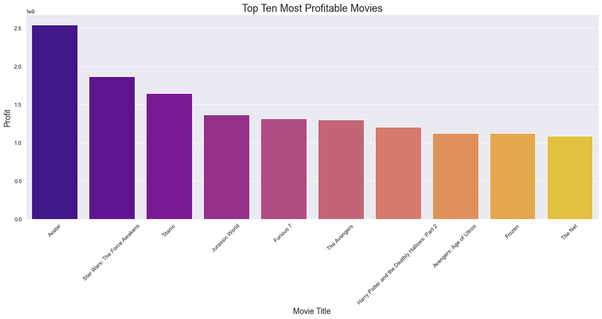

```python
# Sort movies based on profitability (top 10 movies)
sort_p_movies = df.sort_values(by='profit', ascending=False).head(10)

# Plot the top 10 most profitable movies
plt.figure(figsize=(15, 8))
sns.barplot(x=sort_p_movies['original_title'], y=sort_p_movies['profit'], palette='plasma')
plt.xticks(rotation=45)
plt.title('Top Ten Most Profitable Movies', fontsize = 18)
plt.xlabel('Movie Title', fontsize=14)
plt.ylabel('Profit', fontsize = 14)
plt.tight_layout()
plt.show()
```

### Research Question 2: Which Director has the highest rating for the movies

To gain this insight, I have used groupby function and analysed it with the vote average column

```python
# Grouping by the Director and calculating the average review and count of movies

director_rating = df.groupby('director').agg({'vote_average': 'mean', 'id': 'count'}).rename(columns={'id': 'movie_count'}) #agg() function used for the applying multiple aggregation and rename to make the data more understanding

# Removing the directors with less than 7 movies
directorLimit = director_rating[director_rating['movie_count'] > 7]

# Sort directors by average rating in descending order to get the top rated directors accordingly

top_director = directorLimit.sort_values(by='vote_average', ascending=False).head(15)

top_director[['vote_average']]
```

| director | vote_average |
| --- | --- |
| Christopher Nolan | 7.470000 |
| Stanley Kubrick | 7.388889 |
| Quentin Tarantino | 7.354545 |
| Wes Anderson | 7.225000 |
| David Fincher | 7.210000 |
| Joel Coen | 7.060000 |
| Paul Thomas Anderson | 7.037500 |
| Peter Jackson | 7.000000 |
| Martin Scorsese | 6.958621 |
| Danny Boyle | 6.890909 |
| MiloÅ¡ Forman | 6.862500 |
| Jim Jarmusch | 6.845455 |
| unknown | 6.836364 |
| James Cameron | 6.830000 |
| Steven Spielberg | 6.824138 |

```python
# Excluding the 'unknown' values from the column
top_director = top_director[top_director.index != 'unknown']

# Getting the top 15 Directors
top_director_new = top_director.head(15)
```

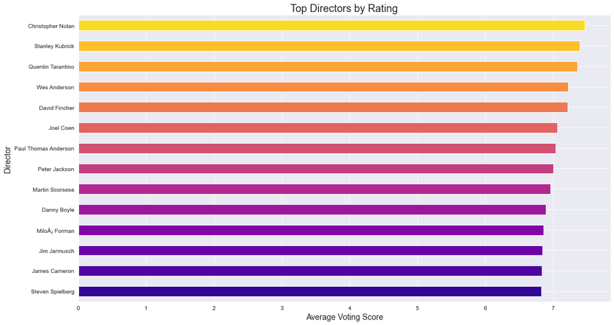

```python
# Plotting the average voting scores for the top directors
plt.figure(figsize=(15, 8))
top_director['vote_average'].sort_values().plot(kind='barh', color=sns.color_palette("plasma", len(top_director)))
plt.title('Top Directors by Rating', fontsize=18)
plt.xlabel('Average Voting Score', fontsize=14)
plt.ylabel('Director', fontsize=14)
plt.tight_layout()
plt.show()
```

### Observation

As expected the most highly rated director is Christopher Nolan, followed by Stanley Kubrick and Quentin Tarantino

### Research Question 3: Which are the top production companies?

**To know and plot the top production comapnies, the production company columns data needs to be splitted**

```python
# Splitting the production companies column and exploding it to count the companies accordingly
production_companies = df['production_companies'].str.split('|').explode()

# Counting the number of movies produced by all companies
production_companies = production_companies.value_counts()

# The top 10 production companies
production_companies.head(10)
```

```
unknown                                   1030
Universal Pictures                         522
Warner Bros.                               509
Paramount Pictures                         431
Twentieth Century Fox Film Corporation     282
Columbia Pictures                          272
New Line Cinema                            219
Metro-Goldwyn-Mayer (MGM)                  218
Walt Disney Pictures                       214
Touchstone Pictures                        178
Name: production_companies, dtype: int64
```

**It is evident that there are many unknown values in the production companies, to exclude these unknow values from the chart, the following code has been processed**

```python
# Excluding the 'unknown' values from the column
production_companies = production_companies[production_companies.index != 'unknown']

# Getting the top 7 production companies
top_production_companies = production_companies.head(7)
```

[figure not shown]

```python
# Plotting

# Pie chart parameters
colors = sns.color_palette("plasma")
explodes = (0.05, 0.05, 0.05, 0.05, 0.05, 0.05, 0.05)  # explode the first three slices for emphasis
sizes = top_producing_companies.values
labels = top_producing_companies.index

# Plotting the pie chart
plt.figure(figsize=(15, 8))
plt.pie(sizes, explode=explodes, labels=labels, colors=colors, autopct='%1.2f%%', startangle=0, shadow=True)
plt.title('Top 7 Production Companies by the number of Movies Produced', fontsize=18)
plt.tight_layout()
plt.show()
```

The top production companies in respect of number of movies produced are -

1. Universal Pictures (21.28%)
2. Warner Bros. (20.75%)
3. Paramount Pictures (17.57%)
4. 20th Century Fox Film Corporation (11.50%)
5. Columbia Pictures (11.09%)
6. New Line Cinema (8.93%)
7. MGM (8.89%)

### Reserach question 4: Which months has witnessed the most popular movies, is there any relation between them?

```python
# Convert the 'release_date' column to datetime format and extract the month
df['release_date'] = df['release_date'].dt.month
```

```python
# Grouping the movies by release month and using the mean function to calculate the average
average_popularity = df.groupby('release_date')['popularity'].mean()
```

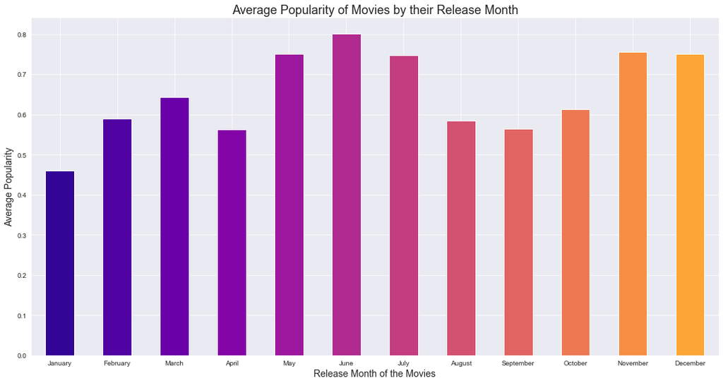

```python
# Plotting average popularity by release month
plt.figure(figsize=(15, 8))
average_popularity.plot(kind='bar', color=sns.color_palette("plasma", 14))
month = ["January", "February", "March", "April", "May", "June", "July", "August", "September", "October", "November", "December"]
plt.title('Average Popularity of Movies by their Release Month', fontsize=18)
plt.ylabel('Average Popularity', fontsize=14)
plt.xlabel('Release Month of the Movies', fontsize=14)
plt.xticks(range(12), month, rotation=0)
plt.tight_layout()
plt.show()
```

[output not shown]

### Research Question 5: Is there any relation between Budget and the revenue of the movies?

```python
# Calculating the correlation between budget and revenue
correlation_coef = df['budget'].corr(df['revenue']) # corr() function is used to calculate the correlation coefficient
print (correlation_coef)
```

```
0.7349279812889292
```

#### The correlation coefficient between the Budget and Revenue is 0.73, which indicates a strong positive correlation which means if the budget of the movies are increased or is more, it is them likely that the revenue of the movie is increased or more.

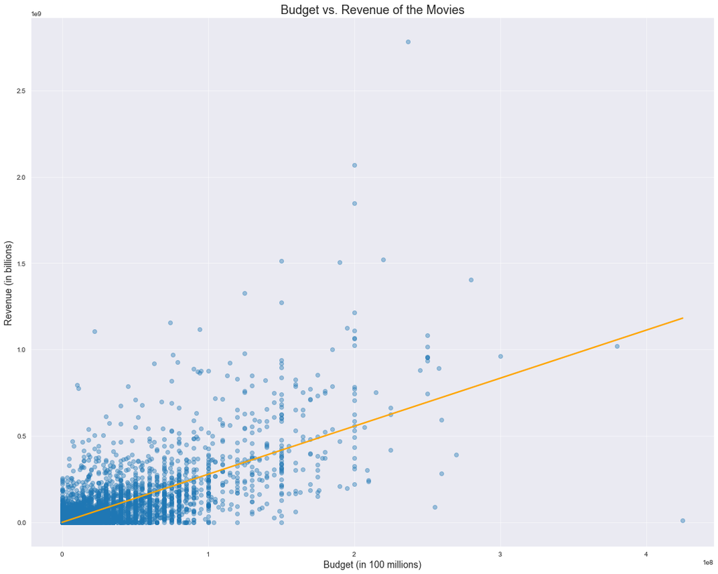

```python
# Scatter plot with regression line for Budget vs Revenue
plt.figure(figsize=(15, 12))
sns.regplot(x=df['budget'], y=df['revenue'], scatter_kws={'alpha':0.4}, line_kws={'color':'orange'}, ci=None)
plt.grid(True, which='both', linestyle='-', linewidth=0.5)
plt.title('Budget vs. Revenue of the Movies', fontsize=18)
plt.xlabel('Budget (in 100 millions)', fontsize=14)
plt.ylabel('Revenue (in billions)', fontsize=14)
plt.tight_layout()
plt.show()
```

### Observation

The above plot conveys that the Revenue and Budget of the movie share the Strong Poitive Correlation, which indicates that if the Budget of the movie is high then the chances of the movie's revenue being more is also high and vice versa.

## Conclusions

The data-driven insights has provided a thorough example and interesting valuable analysis from the dataset which is useful for the stakeholders and people who has interest in the movie industry.

The research questions and their answers in brief-

1. **Which are the top 10 grossing movies?**

2. **Which Director has the highest rating for the movies?**

The most highly rated director is Christopher Nolan, followed by Stanley Kubrick and Quentin Tarantino.

3. **Which are the top production companies and their share?**

The top production companies in respect of number of movies produced are -

Universal Pictures (21.28%) Warner Bros. (20.75%) Paramount Pictures (17.57%) 20th Century Fox Film Corporation (11.50%) Columbia Pictures (11.09%) New Line Cinema (8.93%) MGM (8.89%)

5. **Is there any relation between Budget and the revenue of the movies?Is there any relation between Budget and the revenue of the movies?**

The Revenue and Budget of the movie share the Strong Poitive Correlation, which indicates that if the Budget of the movie is high then the chances of the movie's revenue being more is also high and vice versa.

### Limitations

**Data Type Issues** - Few columns like release_date was not in the correct format, thus changing it to the desired datatype.

**Multivalued Columns**- Few columns like Production Companies, Genres and Cast consists of the multiple values in the single row, thus making it difficult to interpret and and visualise, it needs data handling to split the data in the columns and then processed further for the analysis.